# Analyzing Global Health: Causes of Death Across Countries

By: Muzzamal Saleem

## Introduction

In this tutorial, I will explore into the historical data on causes of death worldwide, shedding light on global health trends and the impact of different diseases over time. By exploring this data, we aim to understand better how diseases affect populations and how effective our health interventions have been. This isn't just about numbers—it's about saving lives by identifying what has worked and what hasn't in public health. For data scientists, this presents a unique opportunity to apply analytical skills to solve real-world problems that can make a difference, making this project both crucial and compelling.

## Data Collection

In this section, we'll cover the initial step of the data science lifecycle: Data Collection. Data collection is a critical phase where data scientists gather information from various sources to address specific questions or hypotheses. In our case, we're using a dataset from Kaggle, a platform that hosts datasets for data science and machine learning projects.

### Dataset Overview

You can download the dataset at [Kaggle - Cause of Deaths Around the World](https://www.kaggle.com/datasets/iamsouravbanerjee/cause-of-deaths-around-the-world). Our dataset, titled "cause_of_deaths.csv", contains information on the causes of death across different countries and years. Each row in the dataset represents a country in a specific year, with columns detailing deaths due to various causes.

### Loading the Dataset

To begin working with this dataset, we first need to load it into our Python environment using the Pandas library, a powerful tool for data manipulation and analysis. If you haven't already installed Pandas, you can do so by running `pip install pandas` in your notebook or command line. For a great introduction to using Pandas, check out the official [10-minute guide to Pandas](https://pandas.pydata.org/docs/user_guide/10min.html). It's a quick and informative read that will get you up to speed on the basics of this powerful tool!

Below is the Python code to load our dataset (make sure the dataset is in your working directory):

```python
import pandas as pd
pd.set_option('display.max_columns', None)

# Load the dataset
data = pd.read_csv('cause_of_deaths.csv')

# Display the first few rows of the dataframe
data.head()
```

|  | Country/Territory | Code | Year | Meningitis | Alzheimer's Disease and Other Dementias | Parkinson's Disease | Nutritional Deficiencies | Malaria | Drowning | Interpersonal Violence | Maternal Disorders | HIV/AIDS | Drug Use Disorders | Tuberculosis | Cardiovascular Diseases | Lower Respiratory Infections | Neonatal Disorders | Alcohol Use Disorders | Self-harm | Exposure to Forces of Nature | Diarrheal Diseases | Environmental Heat and Cold Exposure | Neoplasms | Conflict and Terrorism | Diabetes Mellitus | Chronic Kidney Disease | Poisonings | Protein-Energy Malnutrition | Road Injuries | … |
| --- | --- | --- | --- | --- | --- | --- | --- | --- | --- | --- | --- | --- | --- | --- | --- | --- | --- | --- | --- | --- | --- | --- | --- | --- | --- | --- | --- | --- | --- | --- |
| 0 | Afghanistan | AFG | 1990 | 2159 | 1116 | 371 | 2087 | 93 | 1370 | 1538 | 2655 | 34 | 93 | 4661 | 44899 | 23741 | 15612 | 72 | 696 | 0 | 4235 | 175 | 11580 | 1490 | 2108 | 3709 | 338 | 2054 | 4154 | … |
| 1 | Afghanistan | AFG | 1991 | 2218 | 1136 | 374 | 2153 | 189 | 1391 | 2001 | 2885 | 41 | 102 | 4743 | 45492 | 24504 | 17128 | 75 | 751 | 1347 | 4927 | 113 | 11796 | 3370 | 2120 | 3724 | 351 | 2119 | 4472 | … |
| 2 | Afghanistan | AFG | 1992 | 2475 | 1162 | 378 | 2441 | 239 | 1514 | 2299 | 3315 | 48 | 118 | 4976 | 46557 | 27404 | 20060 | 80 | 855 | 614 | 6123 | 38 | 12218 | 4344 | 2153 | 3776 | 386 | 2404 | 5106 | … |
| 3 | Afghanistan | AFG | 1993 | 2812 | 1187 | 384 | 2837 | 108 | 1687 | 2589 | 3671 | 56 | 132 | 5254 | 47951 | 31116 | 22335 | 85 | 943 | 225 | 8174 | 41 | 12634 | 4096 | 2195 | 3862 | 425 | 2797 | 5681 | … |
| 4 | Afghanistan | AFG | 1994 | 3027 | 1211 | 391 | 3081 | 211 | 1809 | 2849 | 3863 | 63 | 142 | 5470 | 49308 | 33390 | 23288 | 88 | 993 | 160 | 8215 | 44 | 12914 | 8959 | 2231 | 3932 | 451 | 3038 | 6001 | … |

We can also see the last few rows of our dataset.

```python
# Display the last few rows of the DataFrame to verify it's loaded correctly
data.tail()
```

|  | Country/Territory | Code | Year | Meningitis | Alzheimer's Disease and Other Dementias | Parkinson's Disease | Nutritional Deficiencies | Malaria | Drowning | Interpersonal Violence | Maternal Disorders | HIV/AIDS | Drug Use Disorders | Tuberculosis | Cardiovascular Diseases | Lower Respiratory Infections | Neonatal Disorders | Alcohol Use Disorders | Self-harm | Exposure to Forces of Nature | Diarrheal Diseases | Environmental Heat and Cold Exposure | Neoplasms | Conflict and Terrorism | Diabetes Mellitus | Chronic Kidney Disease | Poisonings | Protein-Energy Malnutrition | Road Injuries | … |
| --- | --- | --- | --- | --- | --- | --- | --- | --- | --- | --- | --- | --- | --- | --- | --- | --- | --- | --- | --- | --- | --- | --- | --- | --- | --- | --- | --- | --- | --- | --- |
| 6115 | Zimbabwe | ZWE | 2015 | 1439 | 754 | 215 | 3019 | 2518 | 770 | 1302 | 1355 | 29162 | 104 | 11214 | 16649 | 12974 | 9278 | 48 | 2235 | 16 | 5102 | 37 | 11161 | 13 | 3176 | 2108 | 381 | 2990 | 2373 | … |
| 6116 | Zimbabwe | ZWE | 2016 | 1457 | 767 | 219 | 3056 | 2050 | 801 | 1342 | 1338 | 27141 | 110 | 10998 | 16937 | 13024 | 9065 | 49 | 2296 | 31 | 5002 | 37 | 11465 | 6 | 3259 | 2160 | 393 | 3027 | 2436 | … |
| 6117 | Zimbabwe | ZWE | 2017 | 1460 | 781 | 223 | 2990 | 2116 | 818 | 1363 | 1312 | 24846 | 115 | 10762 | 17187 | 12961 | 8901 | 50 | 2338 | 251 | 4948 | 37 | 11744 | 5 | 3313 | 2196 | 398 | 2962 | 2473 | … |
| 6118 | Zimbabwe | ZWE | 2018 | 1450 | 795 | 227 | 2918 | 2088 | 825 | 1396 | 1294 | 22106 | 121 | 10545 | 17460 | 12860 | 8697 | 51 | 2372 | 0 | 4745 | 37 | 12038 | 9 | 3381 | 2240 | 400 | 2890 | 2509 | … |
| 6119 | Zimbabwe | ZWE | 2019 | 1450 | 812 | 232 | 2884 | 2068 | 827 | 1434 | 1294 | 20722 | 127 | 10465 | 17810 | 12897 | 8609 | 53 | 2403 | 660 | 4635 | 37 | 12353 | 11 | 3460 | 2292 | 405 | 2855 | 2554 | … |

### Next Steps

With our data successfully collected and loaded, we're ready to move on to the next phase of the data science lifecycle: Data Processing. In this next phase, we'll prepare our dataset for analysis, which includes cleaning the data, handling missing values, and potentially reshaping the data for easier analysis.

To make our dataset easier to work with, we'll start by renaming some of the columns to more usable names. Here, we're renaming the column 'Country/Territory' to 'Country' for simplicity.

```python
data = data.rename(columns = {'Country/Territory':'Country'})
data.head()
```

|  | Country | Code | Year | Meningitis | Alzheimer's Disease and Other Dementias | Parkinson's Disease | Nutritional Deficiencies | Malaria | Drowning | Interpersonal Violence | Maternal Disorders | HIV/AIDS | Drug Use Disorders | Tuberculosis | Cardiovascular Diseases | Lower Respiratory Infections | Neonatal Disorders | Alcohol Use Disorders | Self-harm | Exposure to Forces of Nature | Diarrheal Diseases | Environmental Heat and Cold Exposure | Neoplasms | Conflict and Terrorism | Diabetes Mellitus | Chronic Kidney Disease | Poisonings | Protein-Energy Malnutrition | Road Injuries | … |
| --- | --- | --- | --- | --- | --- | --- | --- | --- | --- | --- | --- | --- | --- | --- | --- | --- | --- | --- | --- | --- | --- | --- | --- | --- | --- | --- | --- | --- | --- | --- |
| 0 | Afghanistan | AFG | 1990 | 2159 | 1116 | 371 | 2087 | 93 | 1370 | 1538 | 2655 | 34 | 93 | 4661 | 44899 | 23741 | 15612 | 72 | 696 | 0 | 4235 | 175 | 11580 | 1490 | 2108 | 3709 | 338 | 2054 | 4154 | … |
| 1 | Afghanistan | AFG | 1991 | 2218 | 1136 | 374 | 2153 | 189 | 1391 | 2001 | 2885 | 41 | 102 | 4743 | 45492 | 24504 | 17128 | 75 | 751 | 1347 | 4927 | 113 | 11796 | 3370 | 2120 | 3724 | 351 | 2119 | 4472 | … |
| 2 | Afghanistan | AFG | 1992 | 2475 | 1162 | 378 | 2441 | 239 | 1514 | 2299 | 3315 | 48 | 118 | 4976 | 46557 | 27404 | 20060 | 80 | 855 | 614 | 6123 | 38 | 12218 | 4344 | 2153 | 3776 | 386 | 2404 | 5106 | … |
| 3 | Afghanistan | AFG | 1993 | 2812 | 1187 | 384 | 2837 | 108 | 1687 | 2589 | 3671 | 56 | 132 | 5254 | 47951 | 31116 | 22335 | 85 | 943 | 225 | 8174 | 41 | 12634 | 4096 | 2195 | 3862 | 425 | 2797 | 5681 | … |
| 4 | Afghanistan | AFG | 1994 | 3027 | 1211 | 391 | 3081 | 211 | 1809 | 2849 | 3863 | 63 | 142 | 5470 | 49308 | 33390 | 23288 | 88 | 993 | 160 | 8215 | 44 | 12914 | 8959 | 2231 | 3932 | 451 | 3038 | 6001 | … |

Let's make sure our data doesn't contain any duplicates. Duplicates can lead to skewed results and misleading data interpretations.

```python
duplicates = data.duplicated().sum()
duplicates
```

```
0
```

Nice, we got zero duplicates. Now let's check for any null values.

```python
# Check for null values in the dataset
null_values = data.isnull().sum()
null_values
```

```
Country                                       0
Code                                          0
Year                                          0
Meningitis                                    0
Alzheimer's Disease and Other Dementias       0
Parkinson's Disease                           0
Nutritional Deficiencies                      0
Malaria                                       0
Drowning                                      0
Interpersonal Violence                        0
Maternal Disorders                            0
HIV/AIDS                                      0
Drug Use Disorders                            0
Tuberculosis                                  0
Cardiovascular Diseases                       0
Lower Respiratory Infections                  0
Neonatal Disorders                            0
Alcohol Use Disorders                         0
Self-harm                                     0
Exposure to Forces of Nature                  0
Diarrheal Diseases                            0
Environmental Heat and Cold Exposure          0
Neoplasms                                     0
Conflict and Terrorism                        0
Diabetes Mellitus                             0
Chronic Kidney Disease                        0
Poisonings                                    0
Protein-Energy Malnutrition                   0
Road Injuries                                 0
Chronic Respiratory Diseases                  0
Cirrhosis and Other Chronic Liver Diseases    0
Digestive Diseases                            0
Fire, Heat, and Hot Substances                0
Acute Hepatitis                               0
dtype: int64
```

No null valaues to worry about!

```python
unique_values = data.nunique()
unique_values
```

```
Country                                        204
Code                                           204
Year                                            30
Meningitis                                    2020
Alzheimer's Disease and Other Dementias       3037
Parkinson's Disease                           1817
Nutritional Deficiencies                      2147
Malaria                                       1723
Drowning                                      1875
Interpersonal Violence                        2142
Maternal Disorders                            1818
HIV/AIDS                                      2412
Drug Use Disorders                             876
Tuberculosis                                  2843
Cardiovascular Diseases                       5225
Lower Respiratory Infections                  4106
Neonatal Disorders                            3553
Alcohol Use Disorders                         1287
Self-harm                                     2758
Exposure to Forces of Nature                   478
Diarrheal Diseases                            2874
Environmental Heat and Cold Exposure           714
Neoplasms                                     4814
Conflict and Terrorism                         918
Diabetes Mellitus                             3366
Chronic Kidney Disease                        3246
Poisonings                                    1087
Protein-Energy Malnutrition                   2091
Road Injuries                                 3393
Chronic Respiratory Diseases                  3803
Cirrhosis and Other Chronic Liver Diseases    3443
Digestive Diseases                            4023
Fire, Heat, and Hot Substances                1406
Acute Hepatitis                               1059
dtype: int64
```

Notice that our dataset encompasses data from 204 countries and spans over 30 years. We have a lot of unique data to work with!

## Exploratory Analysis & Data Visualization

In this stage, we delve into the dataset through visualizations and statistical analysis to discover patterns, identify anomalies, and test hypotheses.

### Visualizing the Top 10 Causes of Deaths Globally

### Introduction

This visualization aims to highlight the top 10 causes of death globally, providing a clear and impactful view of major health challenges faced worldwide. By identifying and visualizing these leading causes, we can better understand public health priorities and the importance of medical research and healthcare interventions.

### Data Preparation

First, we need to calculate the total number of deaths for each cause across all countries and years. This step sets the groundwork for identifying the top causes of death globally. Pandas allows us to quickly calculate this with the `sum` method.

```python
total_deaths_per_cause = data.iloc[:, 3:].sum()
total_deaths_per_cause
```

```
Meningitis                                     10524572
Alzheimer's Disease and Other Dementias        29768839
Parkinson's Disease                             7179795
Nutritional Deficiencies                       13792032
Malaria                                        25342676
Drowning                                       10301999
Interpersonal Violence                         12752839
Maternal Disorders                              7727046
HIV/AIDS                                       36364419
Drug Use Disorders                              2656121
Tuberculosis                                   45850603
Cardiovascular Diseases                       447741982
Lower Respiratory Infections                   83770038
Neonatal Disorders                             76860729
Alcohol Use Disorders                           4819018
Self-harm                                      23713931
Exposure to Forces of Nature                    1490132
Diarrheal Diseases                             66235508
Environmental Heat and Cold Exposure            1788851
Neoplasms                                     229758538
Conflict and Terrorism                          3294053
Diabetes Mellitus                              31448872
Chronic Kidney Disease                         28911692
Poisonings                                      2601082
Protein-Energy Malnutrition                    12031885
Road Injuries                                  36296469
Chronic Respiratory Diseases                  104605334
Cirrhosis and Other Chronic Liver Diseases     37479321
Digestive Diseases                             65638635
Fire, Heat, and Hot Substances                  3602914
Acute Hepatitis                                 3784791
dtype: int64
```

The next step is to identify the most prevalent causes. We'll sort these totals in descending order to find the top causes and then select the top 10.

```python
top_causes = total_deaths_per_cause.sort_values(ascending=False).head(10)
top_causes
```

```
Cardiovascular Diseases                       447741982
Neoplasms                                     229758538
Chronic Respiratory Diseases                  104605334
Lower Respiratory Infections                   83770038
Neonatal Disorders                             76860729
Diarrheal Diseases                             66235508
Digestive Diseases                             65638635
Tuberculosis                                   45850603
Cirrhosis and Other Chronic Liver Diseases     37479321
HIV/AIDS                                       36364419
dtype: int64
```

Awesome! Now, let's put Seaborn and Matplotlib to work and create a horizontal bar chart to visually represent our data. This type of chart is excellent for emphasizing comparisons between different causes of death. It’s a simple yet powerful way to see at a glance which health issues are the most lethal worldwide.

To make our visualization even more informative, I'll add labels directly onto the bars. These will show the exact number of deaths for each cause, helping us grasp the data's magnitude without needing to refer back to the axis.

Here are some helpful resources to become more acquianted with the libraries we are using.

- [Seaborn Tutorial](https://seaborn.pydata.org/tutorial.html): Dive deeper into Seaborn and learn how to harness its full potential for creating stunning, informative visualizations.
- [Matplotlib Pyplot API](https://matplotlib.org/3.5.3/api/_as_gen/matplotlib.pyplot.html): Get a comprehensive overview of Matplotlib's plotting API to customize your charts and graphs further.

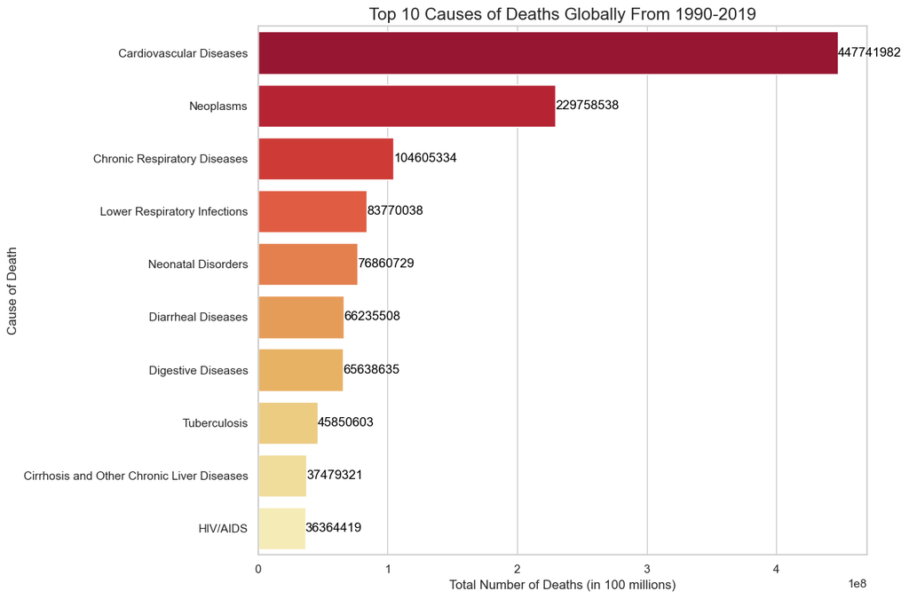

```python
import seaborn as sns
import matplotlib.pyplot as plt

sns.set_theme(style="whitegrid")
palette = sns.color_palette("YlOrRd_r", len(top_causes))
f, ax = plt.subplots(figsize=(12, 8))
sns.barplot(x=top_causes.values, y=top_causes.index, palette=palette)

# Add informative axis label
ax.set_xlabel('Total Number of Deaths (in 100 millions)', fontsize=12)
ax.set_ylabel('Cause of Death', fontsize=12)
ax.set_title('Top 10 Causes of Deaths Globally From 1990-2019', fontsize=16)

# Add value labels for each bar
for i, v in enumerate(top_causes.values):
    ax.text(v, i, str(v), color='black', va='center')

# Show the plot
plt.tight_layout()
plt.show()
```

Interesting, right? Now, let's take a closer look at how different causes contribute to global deaths. We'll use a donut chart to visually represent these percentages.

Let's get started by summing up the total deaths for each cause across all years and countries. Recall, we did this earlier.

```python
total_deaths_per_cause = data.iloc[:, 3:].sum()
```

Next, we sort the causes by the total number of deaths to identify the most significant contributors to global mortality:

```python
sorted_deaths_per_cause = total_deaths_per_cause.sort_values(ascending=False)
```

Now, to make our data pop visually, we're going to use a donut chart—think of it as a pie chart with a cool twist, thanks to the hole in the middle. This little change makes it not only more visually appealing but also easier to interpret. We’ll make sure our chart is perfectly circular with the `plt.axis('equal')` command, and let's add a legend so we can easily identify each cause of death:

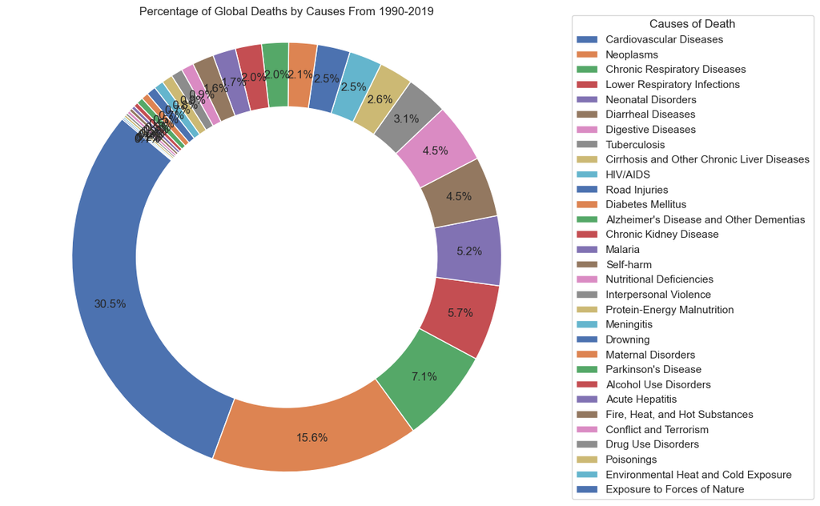

```python
# Plot
plt.figure(figsize=(12, 8))
pie_wedges = plt.pie(sorted_deaths_per_cause, startangle=140, autopct='%1.1f%%', pctdistance=0.85)

# Draw a circle at the center to create a donut chart
centre_circle = plt.Circle((0,0),0.70, fc='white')
fig = plt.gcf()
fig.gca().add_artist(centre_circle)


plt.axis('equal')

# Adding a legend outside the pie chart
plt.legend(pie_wedges[0], sorted_deaths_per_cause.index, title="Causes of Death", loc="center left", bbox_to_anchor=(1, 0, 0.5, 1))

plt.title('Percentage of Global Deaths by Causes From 1990-2019')
plt.tight_layout()
plt.show()
```

Let's dive a bit deeper and look at how the impact of each disease has changed over the years. We're not just looking at raw numbers; instead, we'll calculate the percentage change year over year to see trends in how each disease's death toll has risen or fallen.

We have to make sure to extract the correct columns for diseases, starting from the fourth column since the first three are Country, Code, and Year.

```python
disease_columns = data.columns[3:]  # Skipping Country, Code, Year
```

Group the data by year and sum up the deaths for each cause to see the total impact per year.

```python
annual_deaths = data.groupby('Year').sum()[disease_columns]
```

To spot trends, I calculate the year-over-year percentage change for each disease. This gives us a sense of whether things are getting better or worse.

```python
annual_death_pct_change = annual_deaths.pct_change().dropna() * 100  # Dropping the first year as it'll be NaN
```

Now, for the fun part—visualizing these changes! I'll create a separate plot for each disease to clearly see their trends.

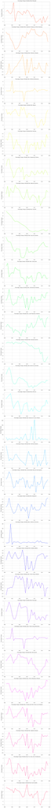

```python
# Setting up multiple plots
num_diseases = len(disease_columns)
fig, axs = plt.subplots(num_diseases, 1, figsize=(10, 5 * num_diseases))
colors = sns.color_palette("hsv", num_diseases)

# Plotting each disease
for i, disease in enumerate(disease_columns):
    axs[i].plot(annual_death_pct_change.index, annual_death_pct_change[disease], label=disease, color=colors[i])
    axs[i].set_title(f'Percentage Change in Mortality Rate: {disease}')
    axs[i].set_ylabel('Percentage Change')
    axs[i].grid(True)


plt.tight_layout()
plt.show()
```

It seems we have a fascinating set of trends and patterns across various diseases over the years.

Now let's dive deeper. In this section, we'll test hypotheses and apply machine learning to uncover further insights from our data. Ready to explore what the numbers reveal about global health trends? Let’s get started!

## Model: Analysis, hypothesis testing, & ML

#### Using Linear Regression to Predict Trends in Disease Mortality

Given our exploratory analysis on the trends and patterns in mortality rates across various diseases, we now turn to a predictive model. Linear regression stands out as a powerful tool for understanding and forecasting future trends based on historical data. To get a clearer picture of how linear regression works and why it's so effective, check out this helpful [video](https://www.youtube.com/watch?v=owI7zxCqNY0) on YouTube. It breaks down the concept in an easy-to-grasp manner, perfect for anyone looking to deepen their understanding.

#### Example Hypothesis for Tuberculosis:

**Hypothesis:** Over the years, public health initiatives and improvements in medical treatments have led to a decrease in mortality rates for Tuberculosis. We expect to see a negative slope in a linear regression model that predicts mortality rate based on the year, confirming this decreasing trend.

**Null Hypothesis:** There is no significant trend (decrease) in the Tuberculosis mortality rates over the years.

To test this hypothesis, we will use linear regression analysis on Tuberculosis mortality data.

First things first, we need to load our dataset and prepare it for analysis. We'll sum up the deaths for each cause by year, which helps us focus on trends over time. Let's focus on Tuberculosis and extract the data related to Tuberculosis deaths from our annual summaries.

```python
# Load the dataset
data = pd.read_csv('cause_of_deaths.csv')

# Sum deaths for each cause by year
annual_deaths = data.groupby('Year').sum()

# Select Tuberculosis for analysis
tb_deaths = annual_deaths['Tuberculosis']
```

Now, let's see if there's a trend in the Tuberculosis mortality rates over the years using linear regression. Before we do that, we transform our years and death counts into the right shape for analysis. This step gets our data ready for the model.

```python
import numpy as np
from sklearn.linear_model import LinearRegression

# Prepare the data for modeling
years = np.array(tb_deaths.index).reshape(-1, 1)
deaths = np.array(tb_deaths.values).reshape(-1, 1)

# Create and fit the model
model = LinearRegression()
model.fit(years, deaths)
```

```
LinearRegression()
```

With our model fitted, we can predict the mortality rates for the given years and plot these predictions against the actual data to see the trend.

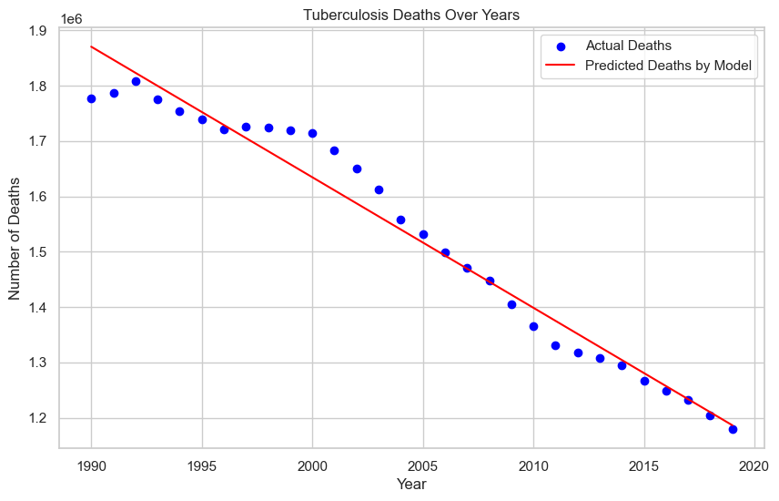

```python
import matplotlib.pyplot as plt

# Predict deaths for the given years
predicted_deaths = model.predict(years)

# Plotting the actual vs predicted deaths
plt.figure(figsize=(10, 6))
plt.scatter(years, deaths, color='blue', label='Actual Deaths')
plt.plot(years, predicted_deaths, color='red', label='Predicted Deaths by Model')
plt.title('Tuberculosis Deaths Over Years')
plt.xlabel('Year')
plt.ylabel('Number of Deaths')
plt.legend()
plt.show()
```

Finally, let's statistically test if there's a significant trend in the data. We'll use a t-test on the slope of the regression line.

```python
from scipy import stats

# Null Hypothesis: No decrease in tuberculosis deaths over the years
slope, intercept, r_value, p_value, std_err = stats.linregress(years.flatten(), deaths.flatten())

print("p-value for hypothesis test:", p_value)

# Determine the outcome of the hypothesis test
if p_value < 0.05:
    print("Reject the null hypothesis - There is a significant decrease in deaths.")
else:
    print("Fail to reject the null hypothesis - No significant change in deaths.")
```

```
p-value for hypothesis test: 3.6757836832769754e-22
Reject the null hypothesis - There is a significant decrease in deaths.
```

Wow, that's a striking result! With a p-value of approximately 3.68e-22, it's extremely low—way below the common threshold of 0.05 used to judge statistical significance. This means we can confidently reject the null hypothesis, which stated that there's no decrease in tuberculosis deaths over the years.

What does this tell us? Well, it's clear evidence that there has been a significant decrease in tuberculosis mortality rates over the years covered by our dataset. This could be attributed to improvements in healthcare, better access to medical treatment, effective public health campaigns, or advancements in medication. It's a positive sign that efforts to combat tuberculosis are paying off!

### Exploring a New Example: Clustering Countries Based on Cardiovascular Disease Deaths

After diving into linear regression, let's try a different approach to understand global health data. This time, we’ll use a clustering algorithm to group countries based on the total deaths from cardiovascular diseases over all the years. Clustering can help us identify patterns that aren't immediately obvious and understand which countries share similar health challenges.

First up, we load our dataset and prepare it by summing up the cardiovascular disease deaths for each country.

```python
import pandas as pd

# Load the dataset
data = pd.read_csv('cause_of_deaths.csv')

# Aggregate 'Cardiovascular Diseases' for each country over all the years
cardiovascular_sum = data.groupby('Country/Territory')['Cardiovascular Diseases'].sum()
```

After aggregation, we'll convert the series to a DataFrame for easier handling and normalize the data to prepare for clustering.

```python
# Convert to DataFrame for easier handling
cardiovascular_sum_df = cardiovascular_sum.reset_index()

# Normalize the data
X = cardiovascular_sum_df[['Cardiovascular Diseases']].values
X_normalized = np.log1p(X)  # Using log1p for normalization to handle large values
```

Now, let’s apply K-Means clustering to group the data into 15 clusters. If you're curious to learn more about how K-Means clustering works, this [video](https://www.youtube.com/watch?v=owI7zxCqNY0) provides a clear and detailed explanation. It's a great resource for visually seeing how data points are grouped into clusters, which can enhance your understanding of the process. Highly recommended for a deeper dive into the topic!

```python
from sklearn.cluster import KMeans

# Initialize KMeans with 15 clusters
kmeans = KMeans(n_clusters=15, random_state=42)
kmeans.fit(X_normalized)

# Assign clusters back to the original data
cardiovascular_sum_df['Cluster'] = kmeans.labels_
```

With our countries now grouped, we can visualize the number of countries in each cluster.

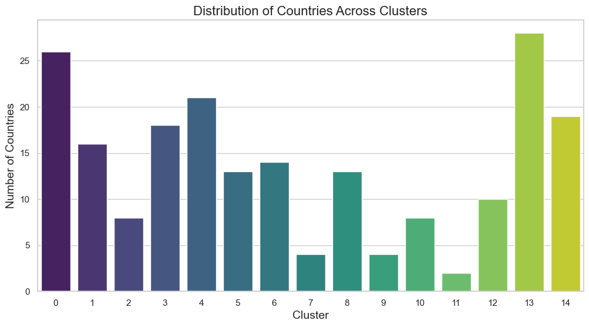

```python
import seaborn as sns
import matplotlib.pyplot as plt

sns.set_style("whitegrid")

# Create a bar plot to visualize the number of countries in each cluster
plt.figure(figsize=(12, 6))
cluster_counts = cardiovascular_sum_df['Cluster'].value_counts().sort_index()
sns.barplot(x=cluster_counts.index, y=cluster_counts.values, palette="viridis")
plt.title('Distribution of Countries Across Clusters', fontsize=16)
plt.xlabel('Cluster', fontsize=14)
plt.ylabel('Number of Countries', fontsize=14)
plt.show()
```

Finally, let's look at which countries are in each cluster and their corresponding cardiovascular death totals.

```python
# Create a list to store the data for each cluster
clusters_countries = []

# Loop through all clusters to gather countries and their death totals
for cluster_number in sorted(cardiovascular_sum_df['Cluster'].unique()):
    cluster_data = cardiovascular_sum_df[cardiovascular_sum_df['Cluster'] == cluster_number]
    countries_in_cluster = cluster_data[['Country/Territory', 'Cardiovascular Diseases']].values
    clusters_countries.append((cluster_number, countries_in_cluster))

# Display the list of all countries and their respective clusters
clusters_countries
```

```
[(0,
  array([['Angola', 525047],
         ['Bosnia and Herzegovina', 500781],
         ['Cambodia', 610359],
         ['Cameroon', 546358],
         ['Chile', 722163],
         ["Cote d'Ivoire", 508223],
         ['Croatia', 750842],
         ['Denmark', 579329],
         ['Dominican Republic', 502583],
         ['Finland', 695601],
         ['Ghana', 794129],
         ['Haiti', 601707],
         ['Kenya', 798827],
         ['Kyrgyzstan', 517868],
         ['Latvia', 544361],
         ['Lithuania', 657865],
         ['Madagascar', 773591],
         ['Moldova', 746997],
         ['Mozambique', 666919],
         ['Norway', 490252],
         ['Peru', 681021],
         ['Slovakia', 818968],
         ['Switzerland', 722512],
         ['Tajikistan', 535923],
         ['Tunisia', 769978],
         ['Uganda', 632868]], dtype=object)),
 (1,
  array([['Antigua and Barbuda', 5264],
         ['Belize', 9582],
         ['Bermuda', 5384],
         ['Brunei', 10987],
         ['Dominica', 7296],
         ['Grenada', 7700],
         ['Guam', 9418],
         ['Kiribati', 8385],
         ['Maldives', 11463],
         ['Micronesia', 8366],
         ['Monaco', 5363],
         ['Saint Lucia', 9576],
```

[output cut: 164 more lines]

```
         ['Cuba', 1003002],
         ['Georgia', 1018279],
         ['Greece', 1453438],
         ['Malaysia', 1194056],
         ['Nepal', 913752],
         ['Netherlands', 1334457],
         ['Portugal', 1168117],
         ['Saudi Arabia', 982797],
         ['Sri Lanka', 1149527],
         ['Sweden', 1213946],
         ['Syria', 1056981],
         ['Taiwan', 981658],
         ['Tanzania', 1155416],
         ['Venezuela', 1158991],
         ['Yemen', 1110837]], dtype=object))]
```

Now that we've identified our clusters, let’s take a closer look at what these groupings tell us. Each cluster tells a story about the countries within it, from those struggling with high death rates to those managing to keep these numbers relatively low. Here are some key observations:

- **Large Clusters**: Clusters like Cluster 9, which includes populous countries like China, India, Russia, and the United States, show extremely high numbers of deaths, reflecting both the population size and the high prevalence of cardiovascular diseases in these countries.
- **Smaller Clusters**: On the other end of the spectrum, we have clusters like Cluster 11 with very small island nations like Niue and Tokelau, showcasing minimal cardiovascular deaths, which could be attributed to their smaller populations.
- **Intermediate Clusters**: Clusters like Cluster 8 include countries with moderate cardiovascular death counts, such as Bangladesh, Egypt, and France. This suggests a mixed influence of healthcare systems' effectiveness and underlying population health dynamics.

## Interpretation: Insight & Policy Decision

As we wrap up our analysis of global health data, here are some clear insights and how they could guide public health policy:

### Policy Recommendations:

- **Strengthen Healthcare Systems:** Strengthening the healthcare system with better facilities and more healthcare professionals is crucial.
- **Educational Programs:** Implement educational programs that promote preventive measures and healthy lifestyle choices, especially in countries with high rates of lifestyle-related diseases.
- **Monitor and Evaluate:** Keep a close eye on health policies to ensure they're effective and tweak them as needed.
- **Research and Development:** Invest in research to delve deeper into the causes of diseases with less significant declines in mortality rates, fostering innovation in medical treatments and public health interventions.

### Conclusion

This project showcases how data science can transform public health strategies. With continued data-driven approaches, we can fight diseases more effectively and lift global health standards. Thanks for joining me on this insightful journey!